# GA4 Certification - 5

Author

Raymond Marquez

Published

March 4, 2026

# 1 **MODULE EVIDENCE**

[figure not shown]

[figure not shown]

## 1.1 Evidence (1 screenshot; labeled)

[figure not shown]

[figure not shown]

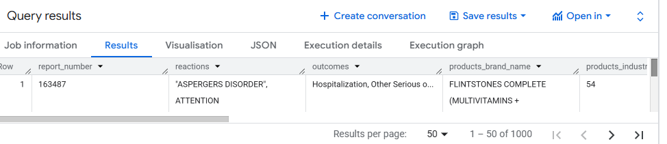

# 2 **SHORT RESPONSES (ANSWER ALL)**

## 2.1 Name one integration (Google Ads, Search Console, BigQuery, Looker Studio, etc.) that would most help your CEP and why

The BigQuery is one of the integrations that would be most beneficial to the CEP. BigQuery enables analysts to store and process large data on food adverse events data set by FDA and GA4 interaction information. With the combination of GA4 and BigQuery, it is possible to conduct more analysis based on their SQL queries to determine the trends in reported food reactions. This aids the public health analyst to identify trends, assess risk factors and make a more informed decision in relation to the food safety monitoring.

## 2.2 Describe one audience you would build in GA4 for activation (who is in it, and what they did)

Several pages having the content regarding food allergy or adverse food reactions reports. Such audience would contain people, who went to FDA safety pages, encountered food recall notice, or downloaded safety report. Such users are willing to show great interest in food safety information. By reaching this audience, the FDA or health organizations will benefit in terms of updating them on new food alerts, food recall, and safety recommendations.

## 2.3 If you had BigQuery export, what’s one analysis you’d do there that’s hard in the GA4 UI?

One of the analyses performed using BigQuery export would be determining the long-term trends in food adverse event report regarding several years and food classes. The interface provided by GA4 cannot be used when dealing with complicated queries of historical data, whilst BigQuery provides the possibility of conducting SQL analysis on large scale data. This enables identifying the relationship between particular foods, geographic areas and reports of the adverse reactions.